# S361 - Recitation4

Serenay Çakar

2026-03-12

## The Acceptance-Rejection Method

In cases where direct sampling methods like inversion or transformation are not feasible, the **acceptance-rejection method** provides an alternative approach to generating random samples from a desired distribution.

Consider two random variables, $X$ and $Y$, with probability density functions (pdf) or probability functions (pf) $f(x)$ and $g(y)$, respectively. We require a constant $c$ such that:

$$f(x) \leq c g(x) \quad \text{for all } x,$$

where $f(x) > 0$.

To generate observations from $X$, follow this algorithm:

**1.** Generate $Y$ from the proposal distribution $g(y)$.

**2.** Generate $U \sim U(0,1)$.

**3.** Accept $Y$ as a sample from $f(X)$ if:
$$U < \frac{f(Y)}{c g(Y)}.$$
Otherwise, reject $Y$ and repeat from step 1.

We try to scale $g(Y)$ by ‘c’ so that it is above $f(Y)$.

In Acceptance-Rejection sampling, we do not need an invertible CDF, which is a necessary condition for the Inverse Transform Method.

Additionally, we do not need a closed-form expression for the PDF.

To enhance computational efficiency, $g(y)$ should be chosen such that:

- It is easy to sample from.
- The ratio $f(y) / g(y)$ is as close to constant as possible.
- The value of $c$ is minimized.

A **uniform distribution** over the support of $f(x)$ is often a convenient choice for $Y$, as uniform samples are computationally simple to generate.

The optimal choice of $c$ is:

$$c = \sup_x \frac{f(x)}{g(x)}.$$

A smaller $c$ increases the acceptance probability and improves efficiency.

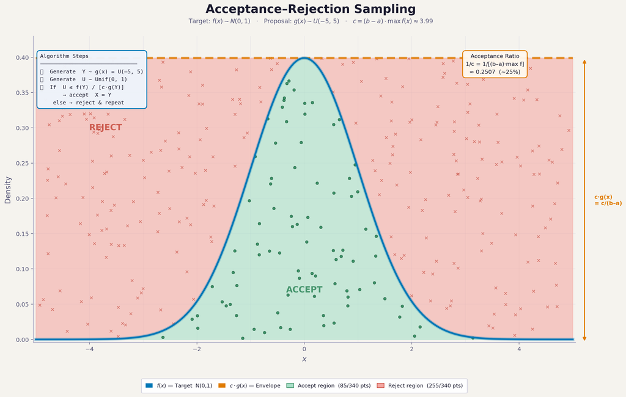

### Acceptance Probability and Number of Iterations

An important property of the acceptance–rejection algorithm is that the **overall probability of accepting a generated candidate in any single iteration** is

$$P(\text{accept}) = \frac{1}{c}.$$

This result follows from the law of total probability. Let $Y \sim g(y)$ and $U \sim U(0,1)$. Then the probability of acceptance is

$$P(\text{accept}) = P\left(U < \frac{f(Y)}{c g(Y)}\right).$$

Taking expectation with respect to $Y$,

$$P(\text{accept})
= \mathbb{E}\left[\frac{f(Y)}{c g(Y)}\right]
= \frac{1}{c} \int \frac{f(y)}{g(y)} g(y)\,dy
= \frac{1}{c} \int f(y)\,dy
= \frac{1}{c}.$$

Thus, on average, **one out of every $c$ generated candidates is accepted**.

### Distribution of the Number of Iterations

Let $N$ denote the number of iterations required until the first accepted sample is obtained. Since each iteration results in acceptance with probability $1/c$, the random variable $N$ follows a **geometric distribution**:

$$N \sim \text{Geometric}\left(p = \frac{1}{c}\right).$$

The probability mass function (pmf) is

$$P(N = k) =
\left(1 - \frac{1}{c}\right)^{k-1}\frac{1}{c},
\qquad k = 1,2,3,\ldots$$

The **expected number of iterations** required to obtain one accepted sample is

$$\mathbb{E}[N] = \frac{1}{p} = c.$$

Thus, the constant $c$ directly determines the **computational efficiency** of the algorithm. A smaller value of $c$:

- increases the acceptance probability,
- reduces the expected number of iterations,
- and improves the efficiency of the sampling procedure.

For this reason, when choosing the proposal distribution $g(y)$, we aim for:

- **easy simulation from $g(y)$**,
- **a small value of $c = \sup_x \frac{f(x)}{g(x)}$**,
- **a shape of $g(y)$ that closely resembles $f(y)$**.

# Part 1: Continuous Case

## Question 1

Generate a random sample of size n = 10000 having density function

$$f(x) = 20x(1-x)^3, \hspace{.2in} 0 <
x < 1$$
$$\textrm{Choose}
\hspace{.1in} g(x) = 1, \hspace{.2in} 0 \leq x \leq 1$$

To determine the constant ‘c’ such that $\frac{f(x)}{g(x)}\leq c$, find the maximum value of $\frac{f(x)}{g(x)} = 20x(1-x)^3$

Take first derivative and set this equals to 0.

$$\frac{d}{dx}[\frac{f(x)}{g(x)}] =
20[(1-x)^3 - 3x(1-x)^2]$$
From here you will get x as 0.25 and thus,

$$\frac{f(x)}{g(x)} \leq
20(\frac{1}{4})(\frac{3}{4})^3 = \frac{135}{64} = c$$

Hence,

$$\frac{f(x)}{cg(x)} =
\frac{256}{27}x(1-x)^3$$

**Step 1:** Generate random numbers $U_1$ and $U_2$ from Uniform(0,1).

**Step 2:** If $U_2 \leq \frac{256}{27} U_1 (1 − U_1)^3$, stop and set $X=U_1$. Otherwise return to step 1.

```r
# Define the target density function f(x)
f <- function(x) 20 * x * (1 - x)^3

# Proposal distribution g(x) ~ Uniform(0,1), so g(x) = 1 for 0 ≤ x ≤ 1

# Find the optimal c by maximizing f(x)/g(x) over [0,1]
fg <- f
result <- optimize(fg, interval = c(0, 1), maximum = TRUE)
c <- result$objective  # Maximum value of f(x), i.e., c = max(f(x)/g(x))

# Print the value of c
print(paste("Optimal c value:", c))
```

```
## [1] "Optimal c value: 2.10937499999007"
```

```r
# Set seed for reproducibility
set.seed(361)

# Define parameters
n <- 10^4  # Number of accepted samples
i <- 0     # Total iterations
k <- 0     # Counter for accepted samples
y <- numeric(n)  # Store accepted samples

# Acceptance-Rejection Sampling Loop
while (k < n) {
  U1 <- runif(1)  # Generate U1 ~ Uniform(0,1) (candidate sample)
  U2 <- runif(1)  # Generate U2 ~ Uniform(0,1) (acceptance check)
  i <- i + 1

  # Accept if U2 ≤ f(U1) / (c * g(U1)), where g(U1) = 1 for Uniform(0,1)
  if (U2 <= f(U1) / c) {
    k <- k + 1
    y[k] <- U1
  }
}

# Print efficiency of the sampling process
print(paste("Total iterations:", i))
```

```
## [1] "Total iterations: 21198"
```

```r
print(paste("Accepted samples:", k))
```

```
## [1] "Accepted samples: 10000"
```

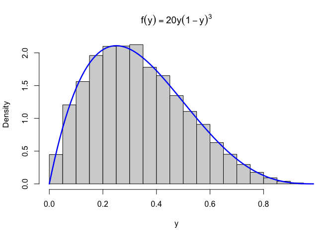

```r
# Plot histogram of the sampled data with true density overlay
hist(y, prob = TRUE, main = expression(f(y) == 20 * y * (1 - y)^3), col="lightgray", border="black")
a <- seq(0, 1, length.out = 100)
lines(a, f(a), col="blue", lwd=2.5)
```

```r
# Summary of generated samples
summary(y)
```

```
##    Min. 1st Qu.  Median    Mean 3rd Qu.    Max.
## 0.00147 0.19622 0.31499 0.33353 0.45207 0.94019
```

Alternatively;

```r
# Set seed for reproducibility
set.seed(361)

# Define number of samples
n <- 10^4

# Generate random samples U1 and U2 from Uniform(0,1)
U1 <- runif(n)
U2 <- runif(n)

# Apply acceptance condition
accepted_samples <- U1[U2 < (256 / 27) * U1 * (1 - U1)^3]

# Check the number of accepted samples
length(accepted_samples)
```

```
## [1] 4678
```

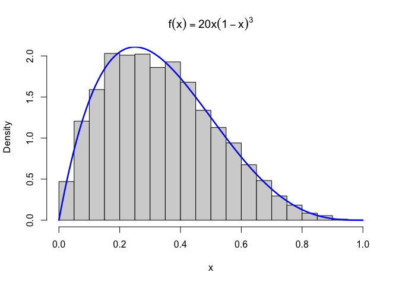

```r
# Plot histogram of the accepted samples with the true density function
hist(accepted_samples, xlab="x", prob=TRUE, main=expression(f(x) == 20 * x * (1 - x)^3), col="lightgray", border="black")
a <- seq(0, 1, length.out=100)
lines(a, 20 * a * (1 - a)^3, col="blue", lwd=2.5)
```

```r
# Summary of U2
summary(U2)
```

```
##      Min.   1st Qu.    Median      Mean   3rd Qu.      Max.
## 0.0000642 0.2525517 0.4910606 0.4996080 0.7534429 0.9998683
```

Alternative visual;

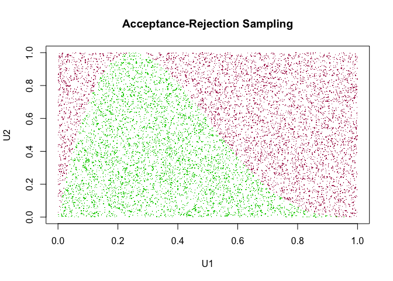

```r
# Scatter plot of all generated points
plot(U1, U2, pch=".", col="maroon", main="Acceptance-Rejection Sampling", xlab="U1", ylab="U2")

# Highlight accepted samples in green
points(accepted_samples, U2[U2 < (256 / 27) * U1 * (1 - U1)^3], pch=".", col="green3")
```

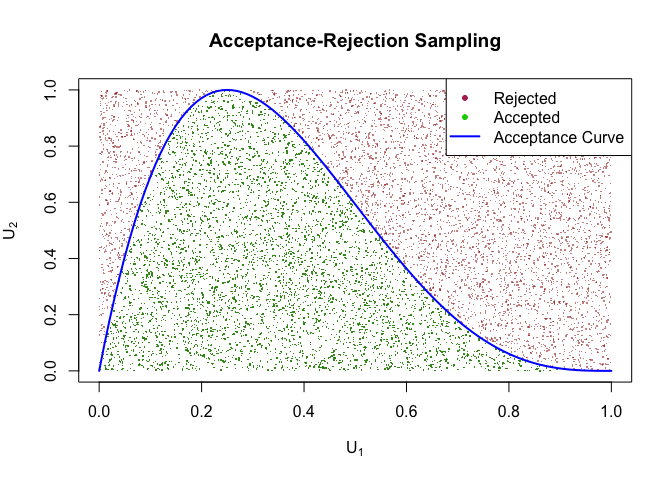

```r
# Enhanced Scatter Plot for Acceptance-Rejection Sampling
plot(U1, U2, pch=".", col=rgb(0.6, 0, 0, 0.5), main="Acceptance-Rejection Sampling",
     xlab=expression(U[1]), ylab=expression(U[2]))

# Highlight accepted samples in green
points(accepted_samples, U2[U2 < (256 / 27) * U1 * (1 - U1)^3], pch=".", col=rgb(0, 0.6, 0, 0.8))

# Add the theoretical acceptance curve for reference
curve((256 / 27) * x * (1 - x)^3, from=0, to=1, col="blue", lwd=2, add=TRUE)
legend("topright", legend=c("Rejected", "Accepted", "Acceptance Curve"),
       col=c("maroon", "green3", "blue"), pch=c(20, 20, NA), lty=c(NA, NA, 1), lwd=c(NA, NA, 2))
```

## Question 2

Use the acceptance-rejection method to generate n=10000 values for a random variable x that has the pdf of
$$f(x)
= \frac{x^2}{9}, \hspace{.2in} 0 < x < 3$$
.

Generate a density histogram for your sampled values and overlay the probability density function of the target distribution. Use the generated data to estimate the mean, standard deviation, and the probability that $X<2$. Compare these estimates with their theoretical counterparts. Additionally, calculate and report the rejection rate.

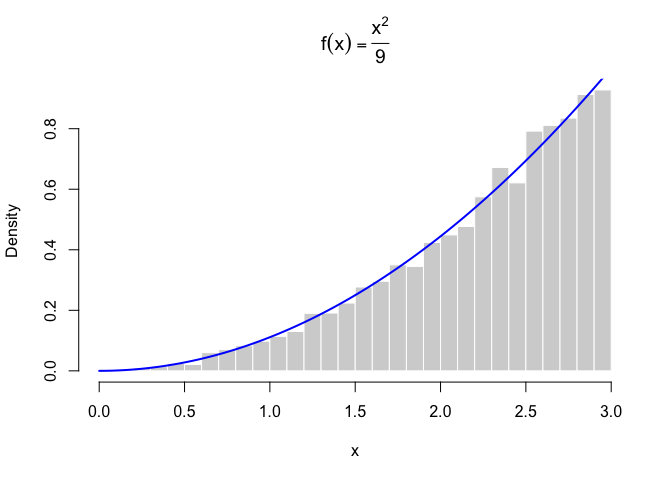

```r
# Define the target PDF
f <- function(x) (x^2) / 9

# Define the proposal distribution g(x) as Uniform(0,3)
g <- function(x) 1/3

# Find the maximum of f(x)/g(x)
ratio_fg <- function(x) f(x) / g(x)
result <- optimize(ratio_fg, interval = c(0, 3), maximum = TRUE)
c <- result$objective  # Maximum scaling constant

# Number of simulations
n <- 10^4
accepted <- numeric(n)  # Store accepted values
accepted_count <- 0  # Counter for accepted values
total_trials <- 0  # Total iterations to calculate rejection rate

# Rejection sampling loop
set.seed(361)
while (accepted_count < n) {
  U1 <- runif(1, min=0, max=3)  # Sample from g(x) = U(0,3)
  U2 <- runif(1)  # Uniform(0,1) for acceptance

  total_trials <- total_trials + 1

  # Accept U1 if U2 < f(U1) / (c * g(U1))
  if (U2 < f(U1) / (c * g(U1))) {
    accepted_count <- accepted_count + 1
    accepted[accepted_count] <- U1
  }
}

# Compute rejection rate
rejection_rate <- 1 - (n / total_trials)

# Generate histogram with theoretical PDF overlay
hist(accepted, probability=TRUE, breaks=30, col="lightgray",
     xlab="x", main=expression(f(x) == frac(x^2, 9)), border="white")

curve(f(x), from=0, to=3, add=TRUE, col="blue", lwd=2)
```

```r
# Summary statistics from the sampled data
mean_sampled <- mean(accepted)
sd_sampled <- sd(accepted)
p_x_less_2 <- mean(accepted < 2)

# Compute theoretical values
theoretical_mean <- integrate(function (x) {x * f(x)}, 0, 3)$value
theoretical_sd <- sqrt(integrate(function (x) {x^2 * f(x)}, 0, 3)$value - theoretical_mean^2)
theoretical_p_x_less_2 <- integrate(f, 0, 2)$value

# Print comparison
cat("Sampled Mean:", mean_sampled, " | Theoretical Mean:", theoretical_mean, "\n")
```

```
## Sampled Mean: 2.252234  | Theoretical Mean: 2.25
```

```r
cat("Sampled SD:", sd_sampled, " | Theoretical SD:", theoretical_sd, "\n")
```

```
## Sampled SD: 0.5814369  | Theoretical SD: 0.5809475
```

```r
cat("P(X < 2) Sampled:", p_x_less_2, " | Theoretical P(X < 2):", theoretical_p_x_less_2, "\n")
```

```
## P(X < 2) Sampled: 0.2927  | Theoretical P(X < 2): 0.2962963
```

```r
cat("Rejection Rate:", rejection_rate, "\n")
```

```
## Rejection Rate: 0.664407
```

## Question 3

Generate a random sample of size n = 10000 having density function
$$f(x) = 3x^2, \hspace{.2in} 0 \leq x \leq
1$$

$$\textrm{Choose} \hspace{.1in} g(x) = 1,
\hspace{.2in} 0 \leq x \leq 1$$

$$\textrm{max}[\frac{f(x)}{g(x)}] = 3 =
c$$
Hence,

$$\frac{f(x)}{cg(x)} = x^2$$

**Step 1:** Generate random numbers $U_1$ and $U_2$ from Uniform(0,1).

**Step 2:** If $U_2 \leq U_1^2$, stop and set $X=U_1$. Otherwise return to step 1.

```r
n <- 10^4
i <- 0 # iteration
k <- 0 # counter for accepted
y <- numeric(n) # random sample

set.seed(1234)
while(TRUE){
  u <- runif(1)
  i <- i + 1
  x <- runif(1)

    if(u < x^2){
      k <- k + 1
      y[k] <- x
    }

    if(k >= n){
      break
    }
}

i;k;length(y)
```

```
## [1] 30060
```

```
## [1] 10000
```

```
## [1] 10000
```

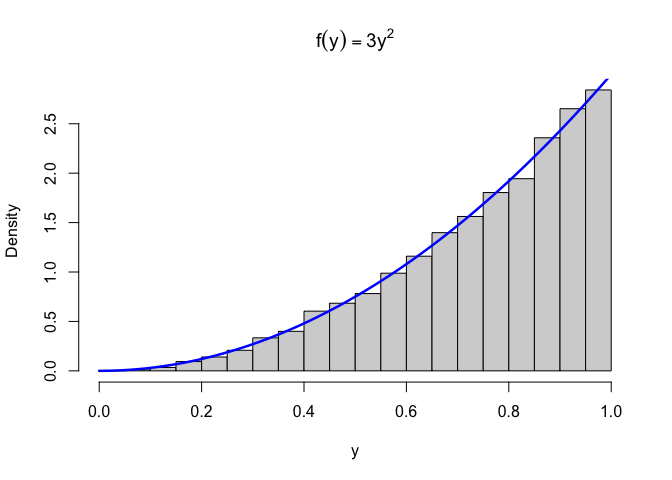

```r
hist(y, prob = TRUE, main =expression(f(y)==3*y^2))
a = seq(0,1,0.01)
lines(a,3*a^2,col="blue",lwd = 2.5)
```

```r
summary(y)
```

```
##    Min. 1st Qu.  Median    Mean 3rd Qu.    Max.
## 0.03529 0.63172 0.79380 0.75167 0.91065 0.99998
```

## Question 4

Let X has the probability density function:

$$f_X(x)= \begin{cases}
\frac{2}{\pi}\sqrt{1-x^2}, & if -1 \le x \le 1 \\
0, & otherwise
\end{cases}$$

Write a function to generate $n=10000$ random numbers from $f(x)$ by using acceptance-rejection method. Calculate the acceptance rate. Graph the histogram of the sample with the theoretical density line superimposed.

- Choose $g(x)= \frac{1}2 , -1 \le x \le 1$
- To determine the constant “c” s.t. $\frac{f(x)}{g(x)}≤c$, the maximum value of $\frac{f(x)}{g(x)}=\frac{4}{\pi}\sqrt{1-x^2}$ should be taken.
- Take first derivative of $\frac{f(x)}{g(x)}$ and equate this to 0.
- $\frac{d}{dx} \frac{f(x)}{g(x)}= \frac{-4x}{\pi \sqrt{1-x^2}}= 0$ and $x=0$ , $c= \frac{4}{\pi}$
- Thus,

$$\frac {f(x)}{cg(x)} = \frac{\frac{2}{\pi}\sqrt{1-x^2}}{\frac{4}{\pi}
\frac{1}{2}} = \sqrt{1-x^2}$$

**Step 1:** Generate two uniform random variables $U_1$ from $U(-1, 1)$ and $U_2$ from $U(0,1)$ where $U_1$ will be our random variable X generated from G function and $U_2$ will be our sample to compare.

**Step 2:** If $U_2 \leq \sqrt{1-U_1^2}$ accept $U_1$, otherwise return to step 1.

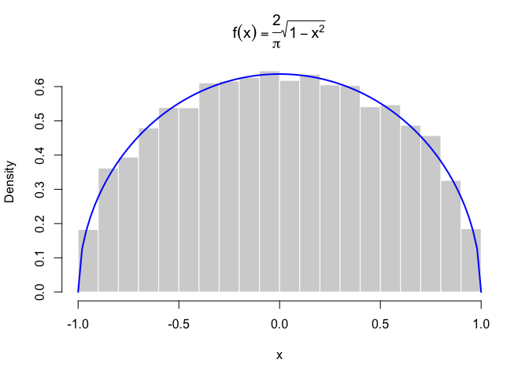

```
##      Min.   1st Qu.    Median      Mean   3rd Qu.      Max.
## -0.998533 -0.398851  0.001461  0.002781  0.406917  0.998908
## Acceptance Rate: 0.7867202
```

```r
set.seed(361)

# Define the target PDF f(x)
f <- function(x) (2/pi) * sqrt(1 - x^2)

# Define the proposal distribution g(x)
g <- function(x) 1/2  # Uniform(-1,1)

# Define the constant c
c <- 4 / pi  # Maximum value of f(x)/g(x)

# Function to generate samples using the Acceptance-Rejection method
generate_samples <- function(n) {
  accepted <- numeric(n)  # Store accepted values
  accepted_count <- 0
  total_trials <- 0

  while (accepted_count < n) {
    U1 <- runif(1, -1, 1)  # Sample from g(x) = U(-1,1)
    U2 <- runif(1, 0, 1)   # Uniform(0,1) for acceptance

    total_trials <- total_trials + 1

    # Accept U1 if U2 <= sqrt(1 - U1^2)
    if (U2 <= sqrt(1 - U1^2)) {
      accepted_count <- accepted_count + 1
      accepted[accepted_count] <- U1
    }
  }

  # Compute acceptance rate
  acceptance_rate <- accepted_count / total_trials

  # Generate histogram with theoretical density
  hist(accepted, probability=TRUE, breaks="Scott", col="lightgray",
       xlab="x", main=expression(f(x) == frac(2, pi) * sqrt(1 - x^2)), border="white")

  curve(f(x), from=-1, to=1, add=TRUE, col="blue", lwd=2)

  # Print summary statistics and acceptance rate
  print(summary(accepted))
  cat("Acceptance Rate:", acceptance_rate, "\n")
}

# Generate 10,000 samples
generate_samples(10000)
```

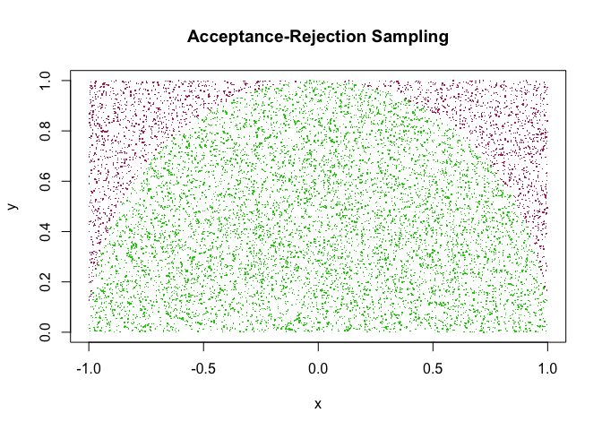

```
## Number of Accepted Cases: 7855
## Acceptance Rate: 0.7855
```

```
##      Min.   1st Qu.    Median      Mean   3rd Qu.      Max.
## -0.998701 -0.392691  0.013210  0.005249  0.403329  0.997715
```

```r
set.seed(361)

alternativefunc <- function(n) {
  # Generate uniform random variables
  x <- runif(n, -1, 1)
  y <- runif(n, 0, 1)

  # Acceptance condition
  accepted <- x[y < sqrt(1 - x^2)]

  # Plot all generated points
  plot(x, y, pch=".", col="maroon", xlab="x", ylab="y",
       main="Acceptance-Rejection Sampling", cex.main=1.2)

  # Highlight accepted points
  points(accepted, y[y < sqrt(1 - x^2)], pch=".", col="green3")

  # Print acceptance rate
  acceptance_rate <- length(accepted) / n
  cat("Number of Accepted Cases:", length(accepted), "\n")

  cat("Acceptance Rate:", acceptance_rate, "\n")

  return(summary(accepted))  # Return summary statistics of accepted values
}

# Run the function with 10,000 samples
alternativefunc(10000)
```

## Question 5

Write a function to generate a random sample of size n from the Beta(a, b) distribution by the acceptance-rejection method. Generate a random sample of size 1000 from the Beta(3,2) distribution. Graph the histogram of the sample with the theoretical Beta(3,2) density superimposed.

Hint: If $X \sim Beta(\alpha,\beta)$ and $f_X (x)=\frac{x^{\alpha-1} (1-x)^{\beta-1}}{B(\alpha,\beta)}$ where $B(\alpha,\beta)=\frac{\Gamma(\alpha)\Gamma(\beta)}{\Gamma(\alpha+\beta)}$ and $\Gamma$ is the Gamma function.

By acceptance-rejection method: $f_X (x)=\frac{x^{a-1} (1-x)^{b-1}}{\frac{\Gamma(a)\Gamma(b)}{\Gamma(a+b)}}$

Note that if $g(x)$ is the Uniform(0,1) density, then

$$\frac{f(x)}{g(x)} = \frac{\Gamma(a + b)}{\Gamma(a)\Gamma(b)} x^{a-1}(1 -
x)^{b-1}$$

where $0 < x < 1$.

The R function below is a generator for arbitrary parameters $a$ and $b$. It can be applied to generate the Beta(3, 2) sample.

The following function first finds the optimal scaling factor c by maximizing f(x)/g(x), where g(x) is a proposal distribution (Uniform in this case). Then, it generates samples accordingly.

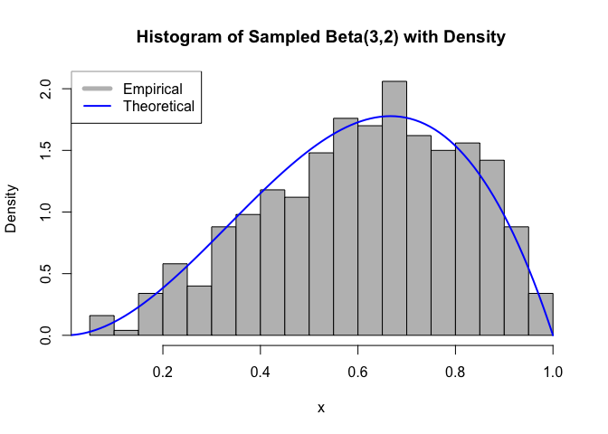

```r
# Function to find the optimal c value
find_c <- function(a, b) {
  fg <- function(x) (gamma(a+b) * x^(a-1) * (1-x)^(b-1)) / (gamma(a) * gamma(b))  # Beta(a,b)/U(0,1)
  c_value <- optimize(fg, interval = c(0, 1), maximum = TRUE)$objective  # Find max
  return(c_value)
}

# Acceptance-Rejection Method for Beta(a, b)
beta_rejection_sample <- function(n, a, b) {
  c <- find_c(a, b)  # Find optimal c
  accept <- numeric(n)
  count <- 0

  while (count < n) {
    X <- runif(1, 0, 1)  # Sample from proposed distribution Uniform(0,1)
    U <- runif(1, 0, 1)  # Sample from Uniform(0, 1) for comparison

    if (U < ((gamma(a+b) * X^(a-1) * (1-X)^(b-1)) / (gamma(a) * gamma(b))/c)) {
      count <- count + 1
      accept[count] <- X
    }
  }
  return(accept)
}

# Generate sample for Beta(3,2)
set.seed(361)

sample_beta <- beta_rejection_sample(1000, 3, 2)

# Plot histogram with theoretical density
hist(sample_beta, probability = TRUE, col = "grey", border = "black",
     breaks = "Scott", main = "Histogram of Sampled Beta(3,2) with Density",
     xlab = "x", ylab = "Density")

# Overlay the theoretical Beta(3,2) density function
beta_pdf <- function(x, a, b) (gamma(a+b) * x^(a-1) * (1-x)^(b-1)) / (gamma(a) * gamma(b))

x_vals <- seq(0, 1, length.out = 100)
y_vals <- sapply(x_vals, function(x) beta_pdf(x, 3, 2))
lines(x_vals, y_vals, col = "blue", lwd = 2)  # Add density curve

# Add legend
legend("topleft", legend = c("Empirical", "Theoretical"),
       col = c("grey", "blue"), lwd = c(5, 2), border = "black")
```

Alternatively, if the proposal distribution $g(x)$ is **Uniform(0,1)**, its density function is:

$$g(x) = 1, \quad 0 < x < 1.$$

Thus, the ratio of target to proposal is:

$$\frac{f(x)}{g(x)} = \frac{\Gamma(a + b)}{\Gamma(a) \Gamma(b)} x^{a-1} (1
- x)^{b-1}.$$

The upper bound **c** for rejection sampling is:

$$c = \frac{\Gamma(a + b)}{\Gamma(a) \Gamma(b)}.$$

To generate a sample from the **Beta(a, b)** distribution using rejection sampling, we follow these steps:

1. Generate $x$ from $g(x) \sim \text{Uniform}(0,1)$.
2. Generate $u \sim \text{Uniform}(0,1)$.
3. Accept $x$ if:
   $$x^{a-1} (1 - x)^{b-1} > u.$$

```r
rBETA <- function(n, a, b) {
  n <- 1000
  k <- 0
  y <- numeric(n)
  while (k < n) {
    u <- runif(1)
    x <- runif(1)
    if (x^(a - 1) * (1 - x)^(b - 1) > u) {
      k <- k + 1
      y[k] <- x
    }
    }
  return(y)
  }
```

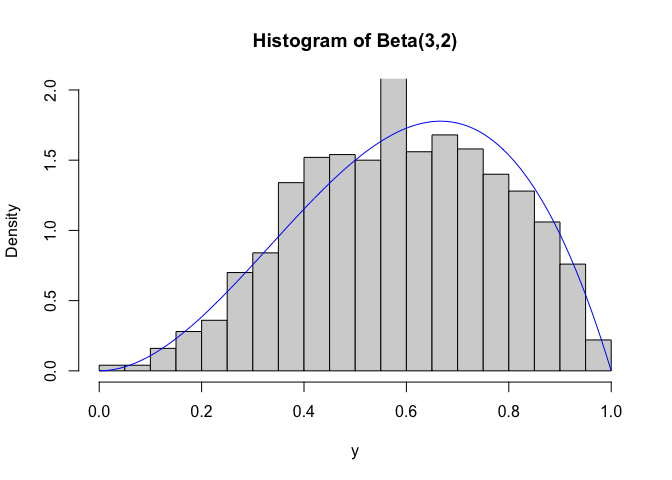

```r
y <- rBETA(1000, a = 3, b = 2)
hist(y, breaks = "Scott", prob = TRUE, ylim = c(0, 2),
     main="Histogram of Beta(3,2)")
z <- seq(0, 1, 0.01)
fz <- 12 * z^2 * (1 - z)
lines(z, fz, col="blue")
```

## Question 6

The von Mises distribution is a distribution on $(- \pi, \pi]$ with density:

$$f(x) \propto e^{\kappa \cos(x - \mu)}$$

for parameters $\kappa > 0$ and $\mu \in (-\pi, \pi]$. The parameter $\mu$ is a location parameter, and fix $\mu = 0$. Use acceptance-rejection method to simulate random variables from the given density.

To implement **rejection sampling**, we use the **uniform distribution** as the proposal distribution:

$$g(x) = \frac{1}{2\pi}, \quad x \in (-\pi, \pi].$$
The rejection sampling constant $c$ must satisfy:

$$c g(x) \geq f(x), \quad \forall x \in (-\pi, \pi].$$

Rearranging:

$$c \geq \frac{f(x)}{g(x)} = 2\pi e^{\kappa \cos(x)}.$$

Since $\cos(x)$ reaches its maximum at $x = 0$ with $\cos(0) = 1$, we get:

$$c = 2\pi e^{\kappa}.$$

```r
von_mises_loop <- function(N, kappa) {
  x <- numeric(N)
  for (i in 1:N) {
    reject <- TRUE
    while (reject) {
      x0 <- runif(1, - pi, pi)
      u <- runif(1)
      reject <- u > exp(kappa * (cos(x0) - 1))
    }
    x[i] <- x0
  }
  x
}
```

We then test the implementation by simulating a large number of variables for different values of the parameter $\kappa$ and compare the histograms to the corresponding theoretical densities.

[figure not shown]

[figure not shown]

```r
x1 <- von_mises_loop(100000, 0.5)
x2 <- von_mises_loop(100000, 2)
# Histograms of these samples should be compared to the density
dvm <- function(x, k) exp(k * cos(x)) / (2 * pi * besselI(k, 0))
```

## Question 7

Derive an acceptance-rejection sampling algorithm for generating random numbers from $N(0,1)$ from a double exponential distribution (aka Laplace) $L(\lambda)$ with $\lambda > 0$, which has the density form:

$$f(x) = \frac{\lambda}{2} \exp(-\lambda |x|).$$

A standard normal distribution has the pdf:

$$\pi(x) = \frac{1}{\sqrt{2\pi}} \exp\left(\frac{-x^2}{2}\right)$$

It is easy to see that, when $x > 0$:

$$\frac{\pi(x)}{f(x)} = \frac{1}{\lambda} \sqrt{\frac{2}{\pi}}
\exp\left(-\frac{x^2 - 2 \lambda |x|}{2}\right) \leq \frac{1}{\lambda}
\sqrt{\frac{2}{\pi}} \exp\left(\frac{\lambda^2}{2}\right)$$

hence we can let:

$$M = \frac{1}{\lambda} \sqrt{\frac{2}{\pi}}
\exp\left(\frac{\lambda^2}{2}\right)$$

You can check the calculation of this upper bound from **Appendix**.

Also,

$$\frac{\pi(x)}{M f(x)} = \exp\left(\frac{-(|x| - \lambda)^2}{2}\right)$$

Therefore, the request acceptance-rejection sampling algorithm should be:

**Algorithm**

1. Draw $X = x$ from $L(\lambda)$
2. Draw $Y = y$ from $\text{Unif}(0, 1)$
3. If $y \leq \exp\left(\frac{-(|x| - \lambda)^2}{2}\right)$, accept $X = x$; otherwise, reject.

Note that in Step 1, we need to draw $X = x$ from $L(\lambda)$. To implement this, we can apply the inverse transformation sampling.

By simple calculation, the CDF for $L(\lambda)$ is:

$$F(x) = \begin{cases}
\frac{1}{2} \exp(\lambda x) & \text{if } x \leq 0 \\
1 - \frac{1}{2} \exp(-\lambda x) & \text{if } x > 0
\end{cases}$$

Thus, taking the inverse transformation yields:

$$F^{-1}(u) = \begin{cases}
\lambda^{-1} \ln(2u) & \text{if } u \leq \frac{1}{2} \\
-\lambda^{-1} \ln(2 - 2u) & \text{if } u > \frac{1}{2}
\end{cases}$$

The new sampling algorithm for $N(0,1)$ is as follows:

**Algorithm**

1. Draw $U = u$ from $\text{Unif}(0,1)$
2. Compute $X = x = F^{-1}(u)$
3. Draw $Y = y$ from $\text{Unif}(0, 1)$
4. If $y \leq \exp\left(\frac{-(|x| - \lambda)^2}{2}\right)$, accept $X = x$; otherwise, reject.

```r
r.mynormal <- function(n, lambda){
  ## This function is for generating a sample of n
  ## observations from N(0,1)
  X <- NULL
  for(i in 1:n) {
    repeat { u <- runif(1)
    if (u<=0.5){
      x <- lambda^(-1)*log(2*u)
    } else{ x <- -lambda^(-1)*log(2-2*u) }
    y <- runif(1)
    if (y <= exp(-(abs(x)-lambda)^2/2)) {
      X[i] <- x
    break
    }
    }
  }
  return(X)
  }
```

Using the above algorithm, let $lambda = 1$ in $L(\lambda)$, we generate a sample of 2000 random numbers from N(0,1), and plot the simulated pdf and the actual pdf:

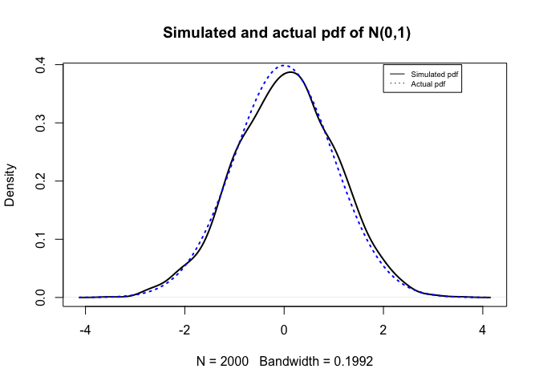

```r
set.seed(361)
mysample <- r.mynormal(n=2000, lambda=1)

plot(density(mysample),lwd=2, main=" Simulated and actual pdf of N(0,1)" )

curve(dnorm(x), add=T, lwd=2, lty=3, col="blue")
legend(x=2, y=0.4, legend=c("Simulated pdf", "Actual pdf"), lty=c(1,3), cex=0.6)
```

# Part 2: Discrete Case

Steps for Discrete Case:

1. Choose a mass function $q_i$ that is easy to sample from.
2. Find a constant c such that $p_Y < c q_Y$ is satisfied.
3. Generate a random number Y from the density $q_i$.
4. Generate a uniform random number U.
5. If $U \leq \frac{p_Y}{cq_Y}$, then accept X=Y, else go to step 3.

## Question 8

Write a function to generate a discrete random variable X that has probability mass function given by

P(X=1)= 0.15 , P(X=2)= 0.22 , P(X=3)= 0.33 , P(X=4)= 0.10 , P(X=5)= 0.20

Since the domain of this density is {1,2,…,5}, we can use the discrete uniform distribution on 1,…, 5 for our $q_i$ , where the probability mass function is given by

$q_i=\frac{1}5 ,i=1,2,…,5$

Then we must find a constant c which we multiply with the discrete uniform pmf so it is above the desired density, that is

$p_y \leq c\times q_y$

Since the biggest pmf for x is 0.33, we can choose maximum c by the equation:

$$c=\frac{max(p_x)}{1/5}=\frac{0.33}{1/5}=1.65$$

```r
# for accepted variates
x <- numeric(n)
y <- numeric(n)

# for rejected variates
rej_x <- numeric(n)
rej_y <- numeric(n)

i <- 1 # initialization of index for accepted r.v's
j <- 1 # initialization of index for rejected r.v's

set.seed(361)

myfunc3 <- function(n,probs) {

  constant <- max(probs)/(1/length(probs))
  cq <- constant*(1/length(probs))
  while(i <= n){
    k <- sample(1:length(probs), size = 1) # random number for q(k)
    u <- runif(1) # random number for comparison
    if (u <= probs[k]/cq){ #then accept
      x[i] <- k
      y[i] <- u * cq
      i <- i + 1
      }else{
        rej_x[j] <- k
        rej_y[j] <- u * cq
        j <- j + 1
      }
    }
  plot(x, y, type="p", col="blue",ylim=c(0,1))
  points(rej_x, rej_y,col="red")
  table(x)/n #estimated probabilities
}
```

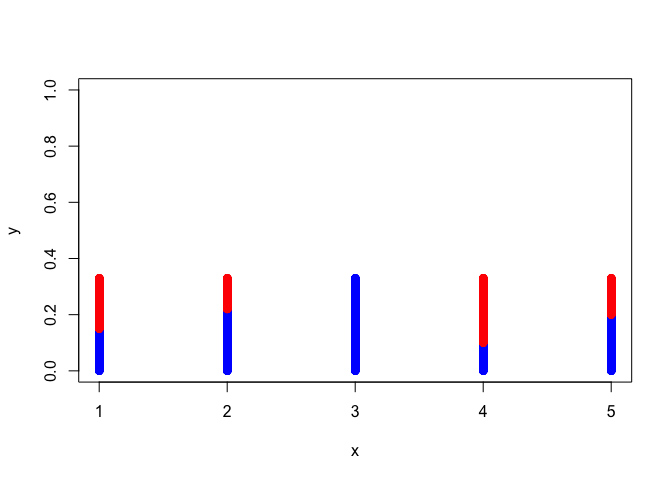

```
## x
##      1      2      3      4      5
## 0.1434 0.2218 0.3357 0.0973 0.2018
```

```r
n <- 10000
probs <- c(0.15, 0.22, 0.33, 0.10, 0.20) #probabilities for the desired density
myfunc3(n,probs)
```

Estimated probabilities are very close to the probabilities of desired density.

# Exercise-1

Let X denote the amount of amount of space occupied by an article in a packing container. The pdf of X is

$$f_X(x)= \begin{cases}
90x^8 (1-x), & 0 < x < 1 \\
0, & otherwise
\end{cases}$$
Write a function to generate n random numbers from the given distribution by using acceptance – rejection method. Run this function n=10000 times and graph the histogram of the sample, add lines to validate and comment.

# Exercise-2

Generate n=10000 random numbers from the following probability density function by using appropriate method. Validate that the sample you have generated really comes from the given distribution.

$$X \sim Laplace(μ=1,β=1) \space \text{where} \space f(x)=\frac{1}{2β}
e^{-\frac{(x-μ)}{β}}, \space x < \mu$$

# Exercise-3

Consider the biweight probability density function,

$$f_X(x) =
\begin{cases}
\frac{15}{16} (1 - x^2)^2, & \text{for } x \in [-1,1] \\
0, & \text{otherwise}
\end{cases}$$

Write a function to generate n random numbers from the given distribution by using acceptance – rejection method. Run this function n=10000 times and graph the histogram of the sample, add lines to validate and comment. Obtain the acceptance and rejection rate for your proposed distribution.

# Appendix: Finding the Upper Bound for $\frac{\pi(x)}{f(x)}$

To find an upper bound for the ratio:

$$\frac{\pi(x)}{f(x)} = \frac{1}{\lambda} \sqrt{\frac{2}{\pi}}
\exp\left(-\frac{x^2 - 2 \lambda |x|}{2}\right)$$

we need to determine the maximum value of this function over all $x$.

The exponent in the exponential function is:

$$-\frac{x^2 - 2\lambda |x|}{2} = -\frac{x^2}{2} + \lambda |x|$$

To maximize this, define:

$$g(x) = -\frac{x^2}{2} + \lambda |x|$$

Since $\exp(g(x))$ is a monotonic function, maximizing $g(x)$ will maximize the entire expression.

### Case 1: $x \geq 0$

$$g(x) = -\frac{x^2}{2} + \lambda x$$

Taking the derivative:

$$\frac{d}{dx} g(x) = -x + \lambda$$

Setting it to zero:

$$-x + \lambda = 0 \Rightarrow x = \lambda$$

### Case 2: $x < 0$

$$g(x) = -\frac{x^2}{2} - \lambda x$$

Derivative:

$$\frac{d}{dx} g(x) = -x - \lambda$$

Setting it to zero:

$$-x - \lambda = 0 \Rightarrow x = -\lambda$$

Since $\lambda > 0$, the maximum occurs at $x = \lambda$ or $x = -\lambda$, both yielding:

$$g(\lambda) = g(-\lambda) = -\frac{\lambda^2}{2} + \lambda^2 =
\frac{\lambda^2}{2}$$

Computing the Upper Bound

Substituting this back into the original fraction:

$$\frac{\pi(x)}{f(x)} \leq \frac{1}{\lambda} \sqrt{\frac{2}{\pi}}
\exp\left(\frac{\lambda^2}{2}\right)$$

Thus, we define:

$$M = \frac{1}{\lambda} \sqrt{\frac{2}{\pi}}
\exp\left(\frac{\lambda^2}{2}\right)$$